# Modelos Locales

Teresa Ortiz

27 de enero de 2015

En esta parte veremos cómo construir los modelos locales que corresponden a factores en la regla del producto para factorizaciones sobre DAGs, y veremos cómo usar datos para ajustar sus parámetros.

### Tablas de probabilidad condicional

En primer lugar, recordemos que siempre podemos hacer representaciones tabulares para la condicional de cada variable dado sus padres: $P(X|Pa(X)),$ donde establecemos, para cada combinación de valores de las variables en $Pa(X)$, una distribución sobre $X$ tal que $\sum_x P(X=x|Pa(X))=1.$

**Ejemplo.** En el ejemplo de la clase anterior construimos directamente las condicionales de llueve (no condicional), regar (no condicional) y mojado dado llueve y regar:

```r
llueve <- c('Sí','No')
regar <- c('Prendido', 'Apagado')
p_llueve <- data.frame(llueve = llueve, prob.l = c(0.1, 0.9))
p_llueve
```

```
##   llueve prob.l
## 1     Sí    0.1
## 2     No    0.9
```

```r
p_regar <- data.frame(regar = regar, prob.r = c(0.2, 0.8))
p_regar
```

```
##      regar prob.r
## 1 Prendido    0.2
## 2  Apagado    0.8
```

```r
mojado <- c('Mojado','Seco')
niveles <- expand.grid(llueve = llueve, regar = regar, mojado = mojado)
p_mojado_lr <- data.frame(niveles, prob_m = NA)
p_mojado_lr$prob_m[1:4] <- c(0.97, 0.9, 0.8, 0.01)
p_mojado_lr$prob_m[5:8]<- 1 - p_mojado_lr$prob_m[1:4]
p_mojado_lr
```

```
##   llueve    regar mojado prob_m
## 1     Sí Prendido Mojado   0.97
## 2     No Prendido Mojado   0.90
## 3     Sí  Apagado Mojado   0.80
## 4     No  Apagado Mojado   0.01
## 5     Sí Prendido   Seco   0.03
## 6     No Prendido   Seco   0.10
## 7     Sí  Apagado   Seco   0.20
## 8     No  Apagado   Seco   0.99
```

Representar los modelos locales de esta forma tiene una desventaja potencial: Esta representación **no explota ninguna regularidad que pueda existir en la condicional**, así que cuando la variable respuesta depende de muchas variables hay muchos parámetros por estimar individualmente (cada probabilidad condicional, menos uno). Esto puede ser difícil de ajustar con datos o demasiado engorroso de elicitar para un experto.

En todos estos casos, podemos reducir el número de parámetros a estimar y obtener una representación más simple, siempre y cuando nuestros modelos más simples ajusten a los datos.

La idea importante es que para especificar las probabilidades condicionales no es necesario dar una tabla completa explícitamente. Podemos tener reglas o modelos simples de las cuales podamos calcular cualquier probabilidad condicional que nos interese.

### Estimación directa por máxima verosimilitud

Cuando usamos datos para estimar los modelos locales, si no hacemos supuestos sobre la estructura de los modelos locales, podemos usar máxima verosimilitud para hacer la estimación.

Para estimar $P(X_i=x|X_1=x_1,\ldots, X_k=x_k)$

utilizamos simplemente $\frac{N(X_i=x,X_1=x_1,\ldots, X_k=x_k)}{N(X_1=x_1,\ldots, X_k=x_k)}.$

Nótese que cuando hay muchas variables de entrada/relativamente pocos datos, esta estimación puede ser muy ruidosa (pocos casos en el denominador), o simplemente infactible. Para modelos simples funciona razonablemente bien.

Una solución (relacionada con un modelo bayesiano) es suavizar los conteos con $\frac{N(X_i=x,X_1=x_1,\ldots, X_k=x_k)+\alpha_x}{N(X_1=x_1,\ldots, X_k=x_k)+\alpha},$ donde $\sum_x \alpha_x=\alpha$.

**Ejemplo.** Consideramos el siguiente ejemplo de datos de la ENIGH 2010 (una observación por hogar, características de hogares y sus habitantes):

```r
library(bnlearn)
library(plyr)
library(dplyr)
load(file='datos/dat_ing.Rdata')

# creamos una base únicamente con variables de interés
dat_ing_f <- dplyr::select(dat_ing, tam_loc, marg, decil, nivelaprob, vehiculo,
                    drenaje, pisos, sexojefe)

black <- data.frame(
  form = c('drenaje', 'nivelaprob', 'decil', 'decil', 'nivelaprob'),
  to = c('decil', 'sexojefe', 'nivelaprob', 'tam_loc', 'marg'))

net_enigh <- hc(dat_ing_f,  score = 'aic', blacklist = black)
net_enigh
```

```
##
##   Bayesian network learned via Score-based methods
##
##   model:
##    [tam_loc][marg|tam_loc][sexojefe|tam_loc]
##    [nivelaprob|tam_loc:marg:sexojefe][decil|marg:nivelaprob]
##    [vehiculo|decil:nivelaprob:sexojefe][drenaje|tam_loc:marg:decil]
##    [pisos|decil:drenaje]
##   nodes:                                 8
##   arcs:                                  15
##     undirected arcs:                     0
##     directed arcs:                       15
##   average markov blanket size:           4.50
##   average neighbourhood size:            3.75
##   average branching factor:              1.88
##
##   learning algorithm:                    Hill-Climbing
##   score:                                 AIC (disc.)
##   penalization coefficient:              1
##   tests used in the learning procedure:  126
##   optimized:                             TRUE
```

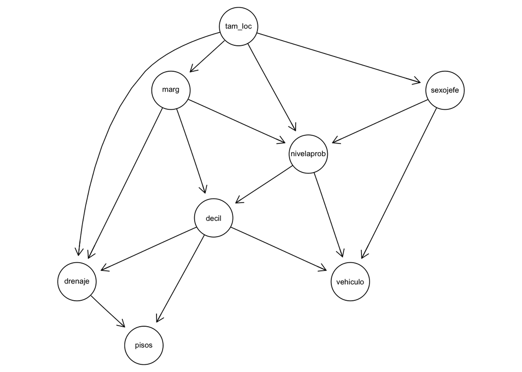

```r
fit_enigh_mle <- bn.fit(net_enigh, data = dat_ing_f, method = 'mle')
graphviz.plot(net_enigh)
```

La estimación por máxima verosimilitud para la condicional de marginación dado tamaño de localidad es

```r
fit_enigh_mle[['marg']]
```

```
##
##   Parameters of node marg (ordinal distribution)
##
## Conditional probability table:
##
##           tam_loc
## marg       100 mil o mas De 15 mil a 100 mil De 2500 a 15 mil
##   Muy bajo    0.89287260          0.33424284       0.14923653
##   Bajo        0.06997547          0.29156110       0.22875252
##   Medio       0.03715193          0.20093549       0.23624316
##   Alto        0.00000000          0.14987332       0.29328724
##   Muy alto    0.00000000          0.02338725       0.09248055
##           tam_loc
## marg       Menos de 2500
##   Muy bajo    0.10946574
##   Bajo        0.14271196
##   Medio       0.21370499
##   Alto        0.31547619
##   Muy alto    0.21864111
```

Que es simplemente (máxima verosimilitud):

```r
tab_1 <- table(dat_ing$marg, dat_ing$tam_loc)
tab_1
```

```
##
##            100 mil o mas De 15 mil a 100 mil De 2500 a 15 mil
##   Muy bajo         12377                1715              518
##   Bajo               970                1496              794
##   Medio              515                1031              820
##   Alto                 0                 769             1018
##   Muy alto             0                 120              321
##
##            Menos de 2500
##   Muy bajo           754
##   Bajo               983
##   Medio             1472
##   Alto              2173
##   Muy alto          1506
```

```r
tab_2 <- prop.table(tab_1, margin = 2)
tab_2
```

```
##
##            100 mil o mas De 15 mil a 100 mil De 2500 a 15 mil
##   Muy bajo    0.89287260          0.33424284       0.14923653
##   Bajo        0.06997547          0.29156110       0.22875252
##   Medio       0.03715193          0.20093549       0.23624316
##   Alto        0.00000000          0.14987332       0.29328724
##   Muy alto    0.00000000          0.02338725       0.09248055
##
##            Menos de 2500
##   Muy bajo    0.10946574
##   Bajo        0.14271196
##   Medio       0.21370499
##   Alto        0.31547619
##   Muy alto    0.21864111
```

En este ejemplo, donde los denominadores son relativamente grandes, no es necesario hacer ningún suavizamiento. Sin embargo, podemos utilizar suavizamiento de conteos de la siguiente forma (*iss* es *imaginary sample size*).

```r
fit_enigh_b <- bn.fit(net_enigh, data = dat_ing_f, method = 'bayes', iss = 100)
fit_enigh_b[['marg']]
```

```
##
##   Parameters of node marg (ordinal distribution)
##
## Conditional probability table:
##
##           tam_loc
## marg       100 mil o mas De 15 mil a 100 mil De 2500 a 15 mil
##   Muy bajo   0.891625261         0.333591932      0.149599542
##   Bajo       0.070209548         0.291117145      0.228546911
##   Medio      0.037445093         0.200930954      0.235983982
##   Alto       0.000360049         0.150116369      0.292620137
##   Muy alto   0.000360049         0.024243600      0.093249428
##           tam_loc
## marg       Menos de 2500
##   Muy bajo   0.109793143
##   Bajo       0.142919138
##   Medio      0.213655432
##   Alto       0.315058585
##   Muy alto   0.218573702
```

```r
prop.table(tab_1 + 100 / (4 * 5), margin = 2)
```

```
##
##            100 mil o mas De 15 mil a 100 mil De 2500 a 15 mil
##   Muy bajo   0.891625261         0.333591932      0.149599542
##   Bajo       0.070209548         0.291117145      0.228546911
##   Medio      0.037445093         0.200930954      0.235983982
##   Alto       0.000360049         0.150116369      0.292620137
##   Muy alto   0.000360049         0.024243600      0.093249428
##
##            Menos de 2500
##   Muy bajo   0.109793143
##   Bajo       0.142919138
##   Medio      0.213655432
##   Alto       0.315058585
##   Muy alto   0.218573702
```

Mayor suavizamiento regulariza más los conteos. Para muestras más chicas, es posible que sea necesario escoger suavizamientos más chicos.

**Ejemplo.** Repetiremos el ejercicio con una muestra chica para ver cómo puede mejorar nuestra estimación el suavizamiento.

```r
library(ggplot2)
library(tidyr)

set.seed(282095)

# tomamos una muestra de tamaño 50
dat_ing_muestra <- sample_n(dat_ing_f, 50)

# veamos la tabla cruda
table(dat_ing_muestra$marg, dat_ing_muestra$tam_loc)
```

```
##
##            100 mil o mas De 15 mil a 100 mil De 2500 a 15 mil
##   Muy bajo            25                   5                0
##   Bajo                 0                   4                3
##   Medio                0                   2                0
##   Alto                 0                   2                2
##   Muy alto             0                   0                0
##
##            Menos de 2500
##   Muy bajo             1
##   Bajo                 0
##   Medio                2
##   Alto                 2
##   Muy alto             2
```

```r
# usamos máxima verosimilitud
fit_enigh_1 <- bn.fit(net_enigh, data = dat_ing_muestra, method='mle')
probs_est_mle <- data.frame(fit_enigh_1[['marg']]$prob)
names(probs_est_mle)[3] <- 'mle'
probs_est_mle
```

```
##        marg             tam_loc       mle
## 1  Muy bajo       100 mil o mas 1.0000000
## 2      Bajo       100 mil o mas 0.0000000
## 3     Medio       100 mil o mas 0.0000000
## 4      Alto       100 mil o mas 0.0000000
## 5  Muy alto       100 mil o mas 0.0000000
## 6  Muy bajo De 15 mil a 100 mil 0.3846154
## 7      Bajo De 15 mil a 100 mil 0.3076923
## 8     Medio De 15 mil a 100 mil 0.1538462
## 9      Alto De 15 mil a 100 mil 0.1538462
## 10 Muy alto De 15 mil a 100 mil 0.0000000
## 11 Muy bajo    De 2500 a 15 mil 0.0000000
## 12     Bajo    De 2500 a 15 mil 0.6000000
## 13    Medio    De 2500 a 15 mil 0.0000000
## 14     Alto    De 2500 a 15 mil 0.4000000
## 15 Muy alto    De 2500 a 15 mil 0.0000000
## 16 Muy bajo       Menos de 2500 0.1428571
## 17     Bajo       Menos de 2500 0.0000000
## 18    Medio       Menos de 2500 0.2857143
## 19     Alto       Menos de 2500 0.2857143
## 20 Muy alto       Menos de 2500 0.2857143
```

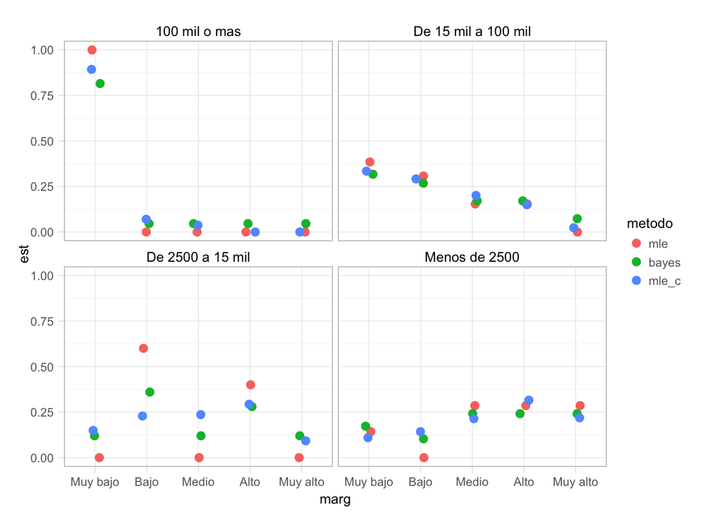

```r
# repetimos con suavizamiento
fit_enigh_2 <- bn.fit(net_enigh, data = dat_ing_muestra, method = 'bayes',
                      iss = 30)

probs_est_bayes <- data.frame(fit_enigh_2[['marg']]$prob)
names(probs_est_bayes)[3] <- 'bayes'
probs_1 <- join(probs_est_mle, probs_est_bayes)
# comparamos con las estimaciones que toman toda la base
tab_df <- data.frame(tab_2)
names(tab_df) <- c('marg', 'tam_loc', 'mle_c')

# las unimos a la base de datos probs_1
probs_2 <- join(probs_1, tab_df)
# creamos dos nuevas variables: método y estimación para poder graficar
probs_2_l <- gather(probs_2, metodo, est, mle, bayes, mle_c)

ggplot(probs_2_l, aes(x = marg, y = est, colour = metodo)) +
  geom_jitter(size=3,position=position_jitter(width=0.1, height=0))+
  facet_wrap(~ tam_loc)
```

Muy poca regularización (iss chica) típicamente no tiene efectos negativos (y conviene hacerla para evitar estimación de ceros), pero puede ser que demasiada regularización sí. Este parámetro puede ser escogido mediante validación cruzada, o desde un punto de vista bayesiano con información previa.

**Ejemplo.** Cuando los modelos son más complejos, la estimación de máxima verosimilitud puede ser muy mala, por ejemplo:

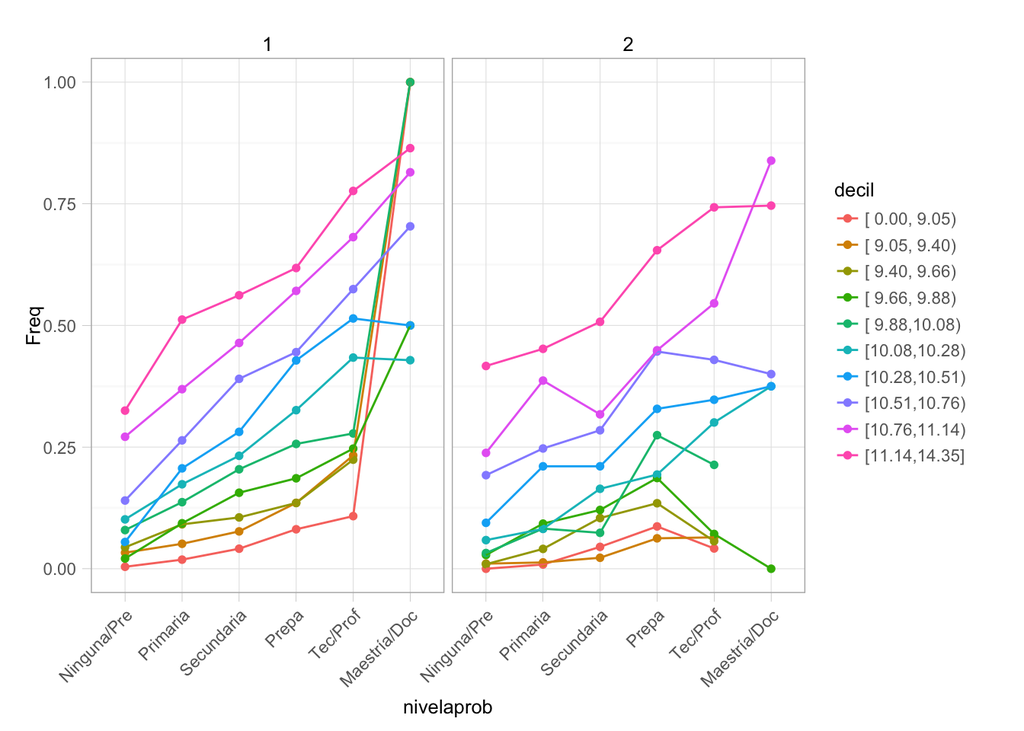

```r
mle_vehiculo <- data.frame(fit_enigh_mle[['vehiculo']]$prob)
mle_vehiculo_true <- filter(mle_vehiculo, vehiculo == 'TRUE',
                            nivelaprob!='No esp')

ggplot(mle_vehiculo_true, aes(x = nivelaprob, y = Freq, colour = decil,
                              group = decil)) +
  facet_wrap(~ sexojefe) +
  geom_point() +
  geom_line() +
  theme(axis.text.x = element_text(angle = 45, hjust = 1))
```

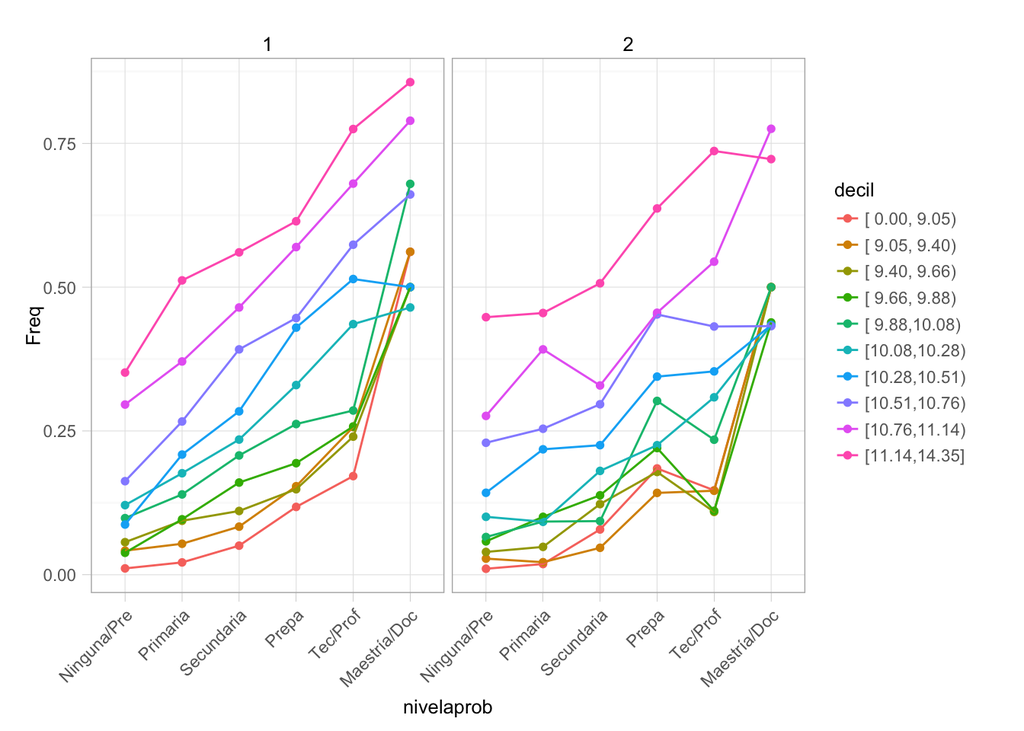

```r
fit_enigh_b <- bn.fit(net_enigh, data = dat_ing_f, method = 'bayes', iss = 1000)
b_vehiculo <- data.frame(fit_enigh_b[['vehiculo']]$prob)
b_vehiculo_true <- filter(b_vehiculo, vehiculo == 'TRUE',
                          nivelaprob!='No esp')

ggplot(b_vehiculo_true, aes(x = nivelaprob, y = Freq, colour = decil,
                              group = decil)) +
  facet_wrap(~ sexojefe) +
  geom_point() +
  geom_line() +
  theme(axis.text.x = element_text(angle = 45, hjust = 1))
```

### Probabilidades condicionales basadas en árboles

Podemos usar árboles de decisión para construir versiones compactas de probabilidades condicionales.

**Ejemplo.** Una carta de recomendación buena del profesor A da una probabilidad de 0.6 de conseguir el trabajo, mientras que una carta mala de 0.4. Para el profesor B, las probabilidades son 0.8 y 0.4. Consideramos la siguiente gráfica:

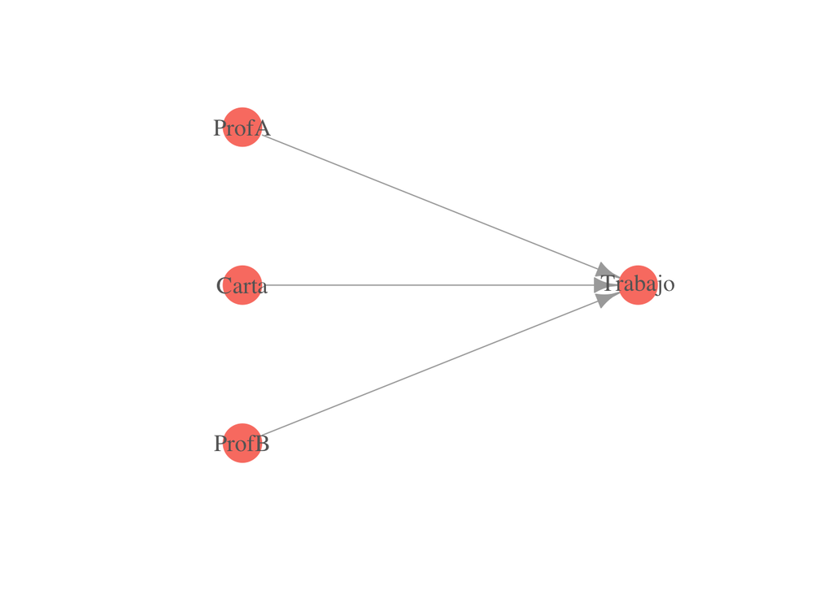

```r
library(igraph)
gr <- graph(c(1, 2, 3, 2, 4, 2))
plot(gr,
  vertex.label = c('ProfA', 'Trabajo', 'ProfB', 'Carta'),
  layout = matrix(c(0, 1, 0.6, 0, 0,-1, 0, 0), byrow = TRUE, ncol = 2),
  vertex.size = 20, vertex.color = 'salmon', vertex.label.cex = 1.2,
  vertex.label.color = 'gray40', vertex.frame.color = NA, asp = 0.8,
  edge.arrow.size = 1)
```

Representamos este escenario mediante un árbol:

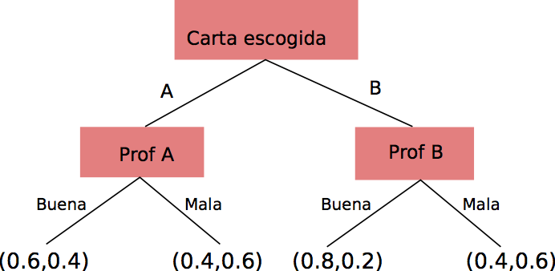

La estructura adicional que observamos es que cuando Carta=A, Trabajo es condicionalmente independiente de Prof B, y cuando Carta=B, Trabajo es condiconalmente independiente de ProfA. Esta es una independencia condicional distinta a las que vimos antes: dice que para **ciertos niveles de alguna variable, existen independencias condicionales entre otras**. Esto **no quiere decir** que dado Carta, Trabajo sea condicionalmente independiente de ProfA o ProfB. Otra manera de decir esto es que estos modelos locales pueden tener información de independencias condicionales en ciertos contextos (para valores particulares de las variables).

**Ejemplo**

```r
library(rpart)
library(rpart.plot)
library(rattle)
set.seed(22857)

# simulamos datos
prof_a <- sample(c('Buena', 'Mala', 'Mala'), 400, replace = T)
prof_b <- sample(c('Buena', 'Buena', 'Mala'), 400, replace = T)
carta <- sample(c('A', 'B'), 400, replace = T)
datos_sim <- data.frame(prof_a, prof_b, carta)

# describimos las probabilidades
probas <- datos_sim %>%
  distinct() %>%
  mutate(proba = (prof_a == 'Mala' & carta == 'A') * 0.4 +
           (prof_b == 'Mala' & carta == 'B') * 0.4 +
           (prof_a == 'Buena' & carta == 'A') * 0.6 +
           (prof_b == 'Buena' & carta == 'B') * 0.8)

probas
```

```
##   prof_a prof_b carta proba
## 1   Mala   Mala     B   0.4
## 2  Buena  Buena     B   0.8
## 3   Mala  Buena     B   0.8
## 4  Buena  Buena     A   0.6
## 5   Mala  Buena     A   0.4
## 6  Buena   Mala     B   0.4
## 7   Mala   Mala     A   0.4
## 8  Buena   Mala     A   0.6
```

```r
# finalmente simulamos si consigue el trabajo
datos_1 <- inner_join(datos_sim, probas)
datos_1$consigue <- rbinom(nrow(datos_1), size = 1, prob = datos_1$prob)

# usamos un árbol de decisión
arbol_1 <- rpart(consigue ~ prof_a + prof_b + carta, datos_1, method = 'class',
                 cp = 0)
printcp(arbol_1)
```

```
##
## Classification tree:
## rpart(formula = consigue ~ prof_a + prof_b + carta, data = datos_1,
##     method = "class", cp = 0)
##
## Variables actually used in tree construction:
## [1] carta  prof_a prof_b
##
## Root node error: 183/400 = 0.4575
##
## n= 400
##
##         CP nsplit rel error  xerror     xstd
## 1 0.174863      0   1.00000 1.00000 0.054447
## 2 0.109290      1   0.82514 0.91257 0.053896
## 3 0.043716      2   0.71585 0.71585 0.051290
## 4 0.000000      3   0.67213 0.72131 0.051389
```

[figure not shown]

```r
fancyRpartPlot(arbol_1)
```

Aunque, sin más información, no hay garantía de recuperar la forma original.

```r
set.seed(46654)

prof_a <- sample(c('Buena', 'Mala', 'Mala'), 300, replace = T)
prof_b <- sample(c('Buena', 'Buena', 'Mala'), 300, replace = T)
carta <- sample(c('A', 'B'), 300, replace = T)
datos_sim <- data.frame(prof_a, prof_b, carta)

# describimos las probabilidades
probas <- datos_sim %>%
  distinct() %>%
  mutate(proba = (prof_a == 'Mala' & carta == 'A') * 0.4 +
           (prof_b == 'Mala' & carta == 'B') * 0.4 +
           (prof_a == 'Buena' & carta == 'A') * 0.6 +
           (prof_b == 'Buena' & carta == 'B') * 0.8)

# finalmente simulamos si consigue el trabajo
datos_1 <- inner_join(datos_sim, probas)
datos_1$consigue <- rbinom(nrow(datos_1), size = 1, prob = datos_1$prob)

# usamos un árbol de decisión
arbol_2 <- rpart(consigue ~ prof_a + prof_b + carta, datos_1, method = 'class',
                 cp = 0)
printcp(arbol_2)
```

```
##
## Classification tree:
## rpart(formula = consigue ~ prof_a + prof_b + carta, data = datos_1,
##     method = "class", cp = 0)
##
## Variables actually used in tree construction:
## [1] carta  prof_a prof_b
##
## Root node error: 127/300 = 0.42333
##
## n= 300
##
##         CP nsplit rel error  xerror     xstd
## 1 0.086614      0   1.00000 1.00000 0.067385
## 2 0.035433      1   0.91339 1.03937 0.067698
## 3 0.019685      3   0.84252 0.92913 0.066621
## 4 0.000000      5   0.80315 0.84252 0.065329
```

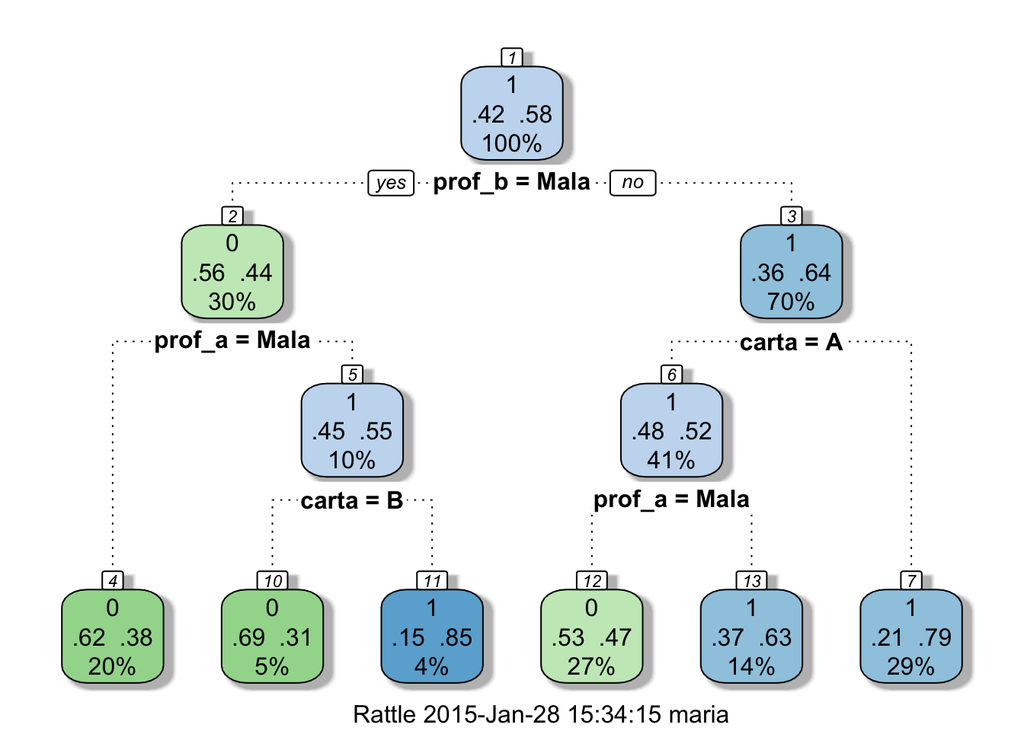

```r
fancyRpartPlot(arbol_2)
```

```r
# usamos un árbol de decisión
arbol_3 <- rpart(consigue ~ prof_a + prof_b + carta, datos_1, method = 'class',
                 cp = 0, cost = c(100, 100, 1))
printcp(arbol_3)
```

```
##
## Classification tree:
## rpart(formula = consigue ~ prof_a + prof_b + carta, data = datos_1,
##     method = "class", cost = c(100, 100, 1), cp = 0)
##
## Variables actually used in tree construction:
## [1] carta  prof_a prof_b
##
## Root node error: 127/300 = 0.42333
##
## n= 300
##
##         CP nsplit rel error  xerror     xstd
## 1 0.065617      0   1.00000 1.00000 0.067385
## 2 0.000000      3   0.80315 0.80315 0.064605
```

[figure not shown]

```r
fancyRpartPlot(arbol_3)
```

### Modelos lineales generalizados

Otra técnica es utilizar modelos logísticos multinomiales (o simplemente logístico cuando la respuesta tiene 2 niveles). La ventaja de este enfoque es que podemos controlar la complejidad del modelo a través de inclusión/exclusión de interacciones y regularización.

```r
net_enigh <- hc(dat_ing_f,  score='aic', blacklist = black)
net_enigh
```

```
##
##   Bayesian network learned via Score-based methods
##
##   model:
##    [tam_loc][marg|tam_loc][sexojefe|tam_loc]
##    [nivelaprob|tam_loc:marg:sexojefe][decil|marg:nivelaprob]
##    [vehiculo|decil:nivelaprob:sexojefe][drenaje|tam_loc:marg:decil]
##    [pisos|decil:drenaje]
##   nodes:                                 8
##   arcs:                                  15
##     undirected arcs:                     0
##     directed arcs:                       15
##   average markov blanket size:           4.50
##   average neighbourhood size:            3.75
##   average branching factor:              1.88
##
##   learning algorithm:                    Hill-Climbing
##   score:                                 AIC (disc.)
##   penalization coefficient:              1
##   tests used in the learning procedure:  126
##   optimized:                             TRUE
```

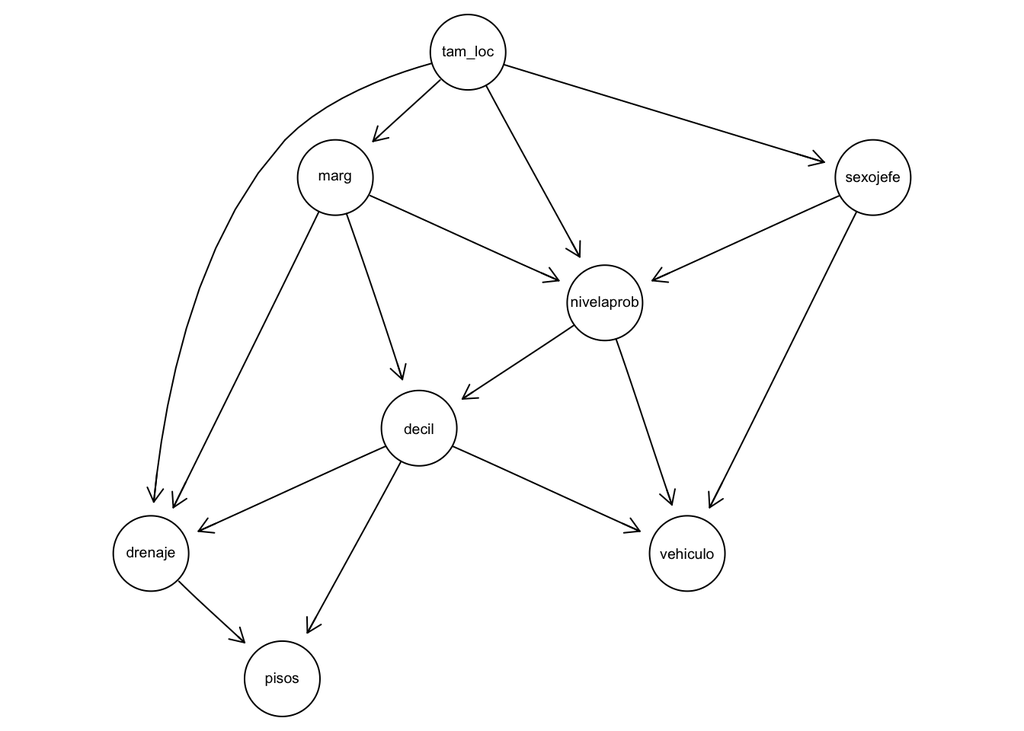

```r
fit_enigh <- bn.fit(net_enigh, data = dat_ing_f, method='mle')
graphviz.plot(net_enigh)
```

Nos interesa el nodo de posesión de vehículo dado decil, nivel aprobado del jefe de familia y sexo del jefe de familia. En este caso, utilizaremos un modelo logístico regularizado.

Los datos se ven como sigue:

```r
library(tidyr)
dat_res <- dat_ing_f %>%
  group_by(sexojefe, nivelaprob, decil, vehiculo) %>%
  summarise(num = n()) %>%
  group_by(sexojefe, nivelaprob, decil) %>%
  mutate(total = sum(num)) %>%
  ungroup() %>%
  mutate(prop = num/total)
dat_res
```

```
## Source: local data frame [228 x 7]
##
##    sexojefe  nivelaprob         decil vehiculo num total        prop
## 1         1      No esp [10.08,10.28)     TRUE   1     1 1.000000000
## 2         1      No esp [10.51,10.76)     TRUE   1     1 1.000000000
## 3         1      No esp [11.14,14.35]     TRUE   2     2 1.000000000
## 4         1 Ninguna/Pre [ 0.00, 9.05)    FALSE 494   496 0.995967742
## 5         1 Ninguna/Pre [ 0.00, 9.05)     TRUE   2   496 0.004032258
## 6         1 Ninguna/Pre [ 9.05, 9.40)    FALSE 352   364 0.967032967
## 7         1 Ninguna/Pre [ 9.05, 9.40)     TRUE  12   364 0.032967033
## 8         1 Ninguna/Pre [ 9.40, 9.66)    FALSE 239   250 0.956000000
## 9         1 Ninguna/Pre [ 9.40, 9.66)     TRUE  11   250 0.044000000
## 10        1 Ninguna/Pre [ 9.66, 9.88)    FALSE 187   191 0.979057592
## ..      ...         ...           ...      ... ...   ...         ...
```

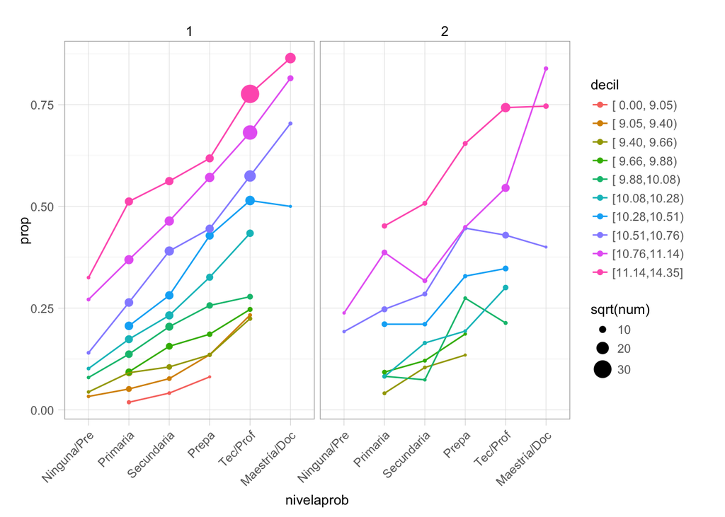

```r
dat_res_sub <- filter(dat_res, vehiculo==TRUE, num > 5)

ggplot(dat_res_sub, aes(x = nivelaprob, y = prop, colour = decil,
  group = decil)) +
  geom_point(aes(size = sqrt(num))) +
  geom_line()+
  facet_wrap(~sexojefe)+
  theme(axis.text.x = element_text(angle = 45, hjust = 1))
```

Comenzamos con un modelo simple, con poca regularización:

```r
library(arm)
set.seed(158865)
# tomamos una muestra de tamaño 10000
dat_ing_m <- dat_ing
# vemos como se ve la variable vehículo
table(dat_ing_m$vehiculo)
```

```
##
## FALSE  TRUE
## 21813  7539
```

```r
# modelo con poca regularización
mod_1 <- bayesglm(vehiculo ~ sexojefe + nivelaprob + decil, data = dat_ing_m,
  family = 'binomial')
display(mod_1)
```

```
## bayesglm(formula = vehiculo ~ sexojefe + nivelaprob + decil,
##     family = "binomial", data = dat_ing_m)
##                        coef.est coef.se
## (Intercept)            -2.05     0.78
## sexojefe2              -0.42     0.04
## nivelaprobNinguna/Pre  -2.47     0.78
## nivelaprobPrimaria     -1.70     0.77
## nivelaprobSecundaria   -1.31     0.77
## nivelaprobPrepa        -0.90     0.77
## nivelaprobTec/Prof     -0.50     0.77
## nivelaprobMaestría/Doc  0.09     0.78
## decil[ 9.05, 9.40)      0.83     0.15
## decil[ 9.40, 9.66)      1.29     0.14
## decil[ 9.66, 9.88)      1.54     0.14
## decil[ 9.88,10.08)      1.87     0.14
## decil[10.08,10.28)      2.16     0.13
## decil[10.28,10.51)      2.50     0.13
## decil[10.51,10.76)      2.83     0.13
## decil[10.76,11.14)      3.27     0.13
## decil[11.14,14.35]      3.77     0.13
## ---
## n = 29352, k = 17
## residual deviance = 25155.9, null deviance = 33445.7 (difference = 8289.8)
```

```r
mod_1$aic
```

```
## [1] 25189.89
```

```r
mod_2 <- bayesglm(vehiculo ~ sexojefe + nivelaprob + decil +
    decil:sexojefe, data = dat_ing_m, family = 'binomial')
display(mod_2)
```

```
## bayesglm(formula = vehiculo ~ sexojefe + nivelaprob + decil +
##     decil:sexojefe, family = "binomial", data = dat_ing_m)
##                              coef.est coef.se
## (Intercept)                  -2.02     0.78
## sexojefe2                    -0.58     0.32
## nivelaprobNinguna/Pre        -2.47     0.77
## nivelaprobPrimaria           -1.71     0.77
## nivelaprobSecundaria         -1.32     0.77
## nivelaprobPrepa              -0.90     0.77
## nivelaprobTec/Prof           -0.50     0.77
## nivelaprobMaestría/Doc        0.08     0.78
## decil[ 9.05, 9.40)            0.92     0.16
## decil[ 9.40, 9.66)            1.30     0.15
## decil[ 9.66, 9.88)            1.48     0.15
## decil[ 9.88,10.08)            1.87     0.15
## decil[10.08,10.28)            2.18     0.15
## decil[10.28,10.51)            2.46     0.14
## decil[10.51,10.76)            2.78     0.14
## decil[10.76,11.14)            3.23     0.14
## decil[11.14,14.35]            3.70     0.15
## sexojefe2:decil[ 9.05, 9.40) -0.69     0.42
## sexojefe2:decil[ 9.40, 9.66) -0.05     0.36
## sexojefe2:decil[ 9.66, 9.88)  0.29     0.35
## sexojefe2:decil[ 9.88,10.08) -0.04     0.34
## sexojefe2:decil[10.08,10.28) -0.04     0.34
## sexojefe2:decil[10.28,10.51)  0.24     0.33
## sexojefe2:decil[10.51,10.76)  0.24     0.33
## sexojefe2:decil[10.76,11.14)  0.21     0.33
## sexojefe2:decil[11.14,14.35]  0.38     0.33
## ---
## n = 29352, k = 26
## residual deviance = 25130.9, null deviance = 33445.7 (difference = 8314.7)
```

```r
mod_2$aic
```

```
## [1] 25182.93
```

```r
mod_3 <- bayesglm(vehiculo ~ sexojefe + nivelaprob + decil +
    sexojefe:nivelaprob + decil:sexojefe, data = dat_ing_m, family='binomial')
display(mod_3)
```

```
## bayesglm(formula = vehiculo ~ sexojefe + nivelaprob + decil +
##     sexojefe:nivelaprob + decil:sexojefe, family = "binomial",
##     data = dat_ing_m)
##                                  coef.est coef.se
## (Intercept)                      -1.99     0.78
## sexojefe2                        -0.59     0.98
## nivelaprobNinguna/Pre            -2.54     0.77
## nivelaprobPrimaria               -1.75     0.77
## nivelaprobSecundaria             -1.32     0.77
## nivelaprobPrepa                  -0.94     0.77
## nivelaprobTec/Prof               -0.46     0.77
## nivelaprobMaestría/Doc            0.20     0.78
## decil[ 9.05, 9.40)                0.92     0.16
## decil[ 9.40, 9.66)                1.29     0.15
## decil[ 9.66, 9.88)                1.47     0.15
## decil[ 9.88,10.08)                1.86     0.15
## decil[10.08,10.28)                2.16     0.15
## decil[10.28,10.51)                2.44     0.14
## decil[10.51,10.76)                2.76     0.14
## decil[10.76,11.14)                3.20     0.14
## decil[11.14,14.35]                3.65     0.15
## sexojefe2:nivelaprobNinguna/Pre   0.14     0.96
## sexojefe2:nivelaprobPrimaria      0.08     0.95
## sexojefe2:nivelaprobSecundaria   -0.13     0.95
## sexojefe2:nivelaprobPrepa         0.12     0.95
## sexojefe2:nivelaprobTec/Prof     -0.28     0.95
## sexojefe2:nivelaprobMaestría/Doc -0.52     0.97
## sexojefe2:decil[ 9.05, 9.40)     -0.68     0.42
## sexojefe2:decil[ 9.40, 9.66)     -0.02     0.36
## sexojefe2:decil[ 9.66, 9.88)      0.33     0.35
## sexojefe2:decil[ 9.88,10.08)      0.02     0.34
## sexojefe2:decil[10.08,10.28)      0.05     0.34
## sexojefe2:decil[10.28,10.51)      0.32     0.33
## sexojefe2:decil[10.51,10.76)      0.34     0.33
## sexojefe2:decil[10.76,11.14)      0.35     0.33
## sexojefe2:decil[11.14,14.35]      0.55     0.33
## ---
## n = 29352, k = 32
## residual deviance = 25111.5, null deviance = 33445.7 (difference = 8334.2)
```

```r
mod_3$aic
```

```
## [1] 25175.47
```

Podemos incluir la interacción faltante:

```r
mod_4 <- bayesglm(vehiculo ~ sexojefe + nivelaprob + decil +
    sexojefe:nivelaprob + decil:sexojefe + nivelaprob:decil,
    data = dat_ing_m, family='binomial')
mod_4$aic
```

```
## [1] 25220.32
```

Ahora podemos ver las probabilidades estimadas del modelo 3:

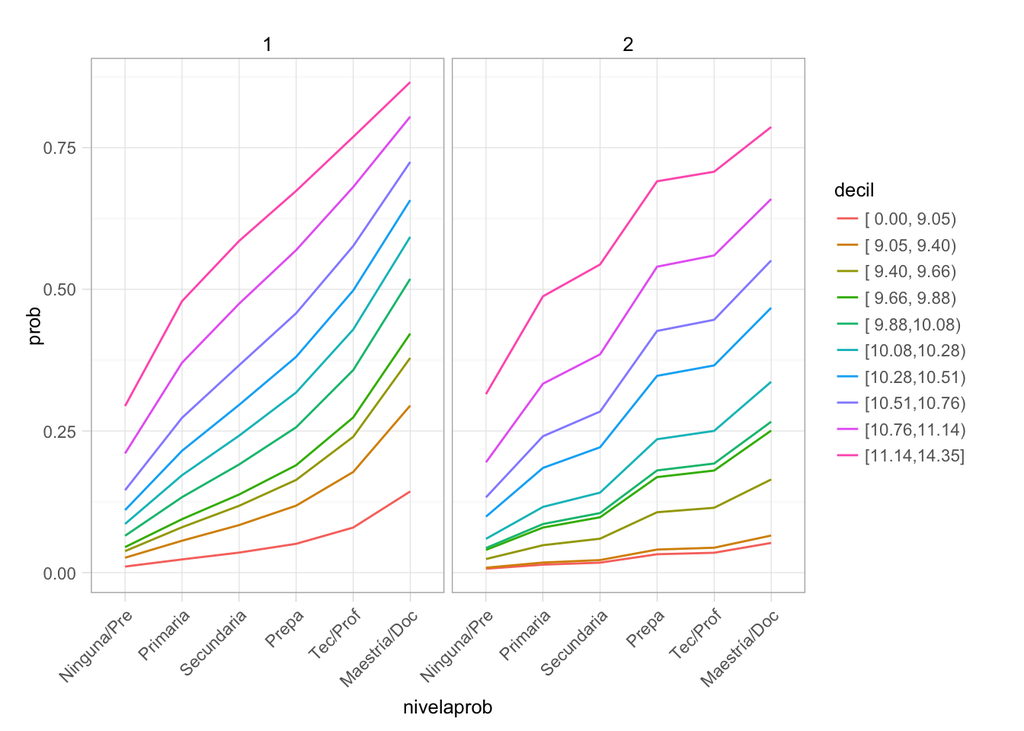

```r
grid_1 <- expand.grid(list(sexojefe = unique(dat_ing$sexojefe),
  nivelaprob = unique(dat_ing$nivelaprob),
  decil = unique(dat_ing$decil)), stringsAsFactors=FALSE)
grid_1$prob <- predict(mod_3, grid_1, type='response')

grid_2 <- filter(grid_1, nivelaprob!='No esp')
ggplot(grid_2, aes(x = nivelaprob, y = prob, colour = decil, group = decil)) +
  geom_line() +
  facet_wrap(~ sexojefe) +
  theme(axis.text.x=element_text(angle = 45, hjust = 1))
```

Y podemos incluir intervalos de probabilidad.

```r
sims_1 <- sim(mod_3, 100)
mod_3$coefficients <- sims_1@coef[3,]
grid_1$prob <- predict(mod_3, grid_1, type='response')
display(mod_3)
```

```
## bayesglm(formula = vehiculo ~ sexojefe + nivelaprob + decil +
##     sexojefe:nivelaprob + decil:sexojefe, family = "binomial",
##     data = dat_ing_m)
##                                  coef.est coef.se
## (Intercept)                      -0.87     0.78
## sexojefe2                        -3.04     0.98
## nivelaprobNinguna/Pre            -3.58     0.77
## nivelaprobPrimaria               -2.74     0.77
## nivelaprobSecundaria             -2.20     0.77
## nivelaprobPrepa                  -1.90     0.77
## nivelaprobTec/Prof               -1.35     0.77
## nivelaprobMaestría/Doc           -0.60     0.78
## decil[ 9.05, 9.40)                0.80     0.16
## decil[ 9.40, 9.66)                1.14     0.15
## decil[ 9.66, 9.88)                1.37     0.15
## decil[ 9.88,10.08)                1.61     0.15
## decil[10.08,10.28)                1.95     0.15
## decil[10.28,10.51)                2.17     0.14
## decil[10.51,10.76)                2.55     0.14
## decil[10.76,11.14)                3.06     0.14
## decil[11.14,14.35]                3.49     0.15
## sexojefe2:nivelaprobNinguna/Pre   2.01     0.96
## sexojefe2:nivelaprobPrimaria      2.01     0.95
## sexojefe2:nivelaprobSecundaria    1.77     0.95
## sexojefe2:nivelaprobPrepa         2.16     0.95
## sexojefe2:nivelaprobTec/Prof      1.65     0.95
## sexojefe2:nivelaprobMaestría/Doc  1.40     0.97
## sexojefe2:decil[ 9.05, 9.40)     -0.42     0.42
## sexojefe2:decil[ 9.40, 9.66)      0.64     0.36
## sexojefe2:decil[ 9.66, 9.88)      0.78     0.35
## sexojefe2:decil[ 9.88,10.08)      0.79     0.34
## sexojefe2:decil[10.08,10.28)      0.64     0.34
## sexojefe2:decil[10.28,10.51)      0.91     0.33
## sexojefe2:decil[10.51,10.76)      0.88     0.33
## sexojefe2:decil[10.76,11.14)      0.93     0.33
## sexojefe2:decil[11.14,14.35]      1.15     0.33
## ---
## n = 29352, k = 32
## residual deviance = 25111.5, null deviance = 33445.7 (difference = 8334.2)
```

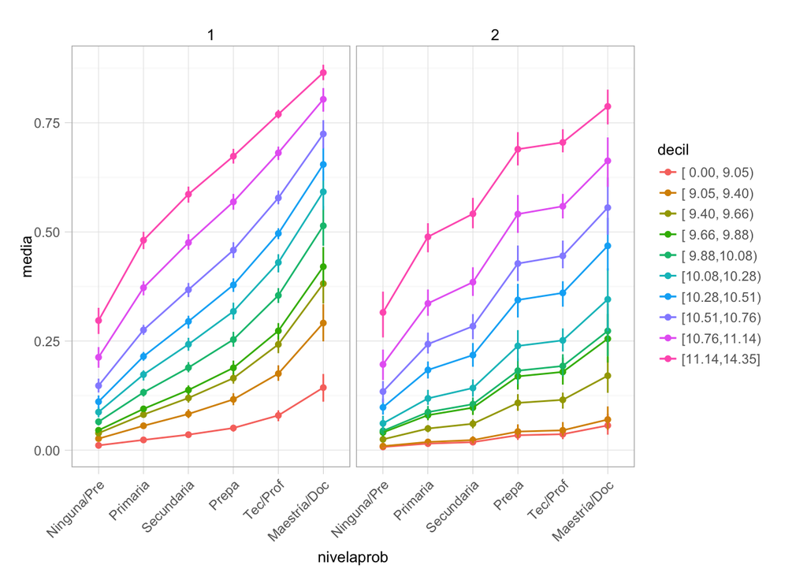

```r
dat_x <- ddply(data.frame(i=1:100), 'i', function(df){
  mod_3$coefficients <- sims_1@coef[df$i,]
  grid_1$prob <- predict(mod_3, grid_1, type='response')
  grid_1$sim.no <- df$i
  grid_1
})

dat_x_1 <- ddply(dat_x, c('sexojefe','nivelaprob','decil'), summarise,
  media=mean(prob), q.10=quantile(prob, 0.1), q.90=quantile(prob,0.9))
dat_x_2 <- subset(dat_x_1, nivelaprob!='No esp')
ggplot(dat_x_2, aes(x=nivelaprob, y=media, colour=decil, group=decil, ymin=q.10,ymax=q.90))+
  geom_point()+geom_line()+
  facet_wrap(~sexojefe) + geom_linerange()+
  theme(axis.text.x=element_text(angle=45, hjust = 1))
```

Finalmente checamos la calibración del modelo con los datos (las probabilidades estimadas reflejan probabilidades empíricas:

```r
library(Hmisc)
```

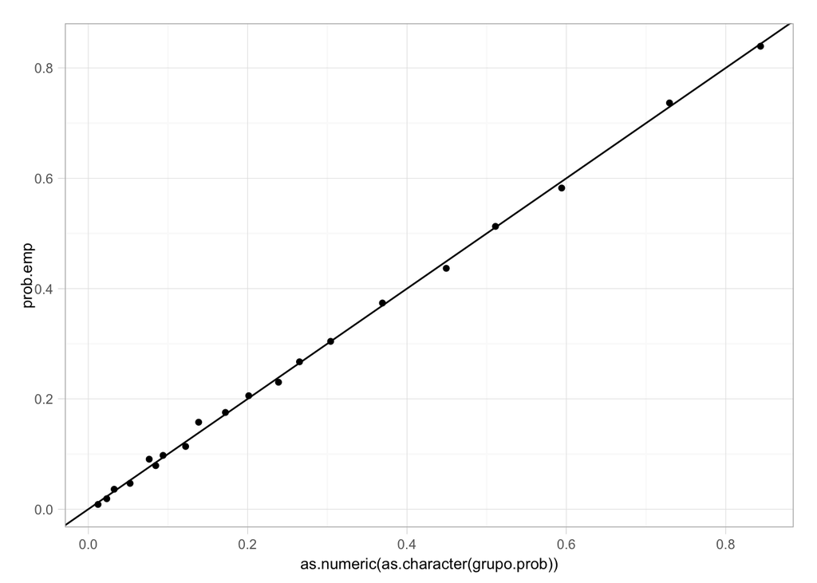

```r
dat_ing$prob.1 <- predict(mod_3, type='response')
dat_ing$grupo.prob <- cut2(dat_ing$prob.1, g=20, levels.mean=TRUE)
dat.cal <- ddply(dat_ing, c('grupo.prob'), summarise, total=length(sexojefe),
  total.vehiculo=sum(vehiculo=='TRUE'))
dat.cal$prob.emp <- dat.cal$total.vehiculo/dat.cal$total
ggplot(dat.cal, aes(x=as.numeric(as.character(grupo.prob)), y=prob.emp)) + geom_point() +
  geom_abline(intercept=0,slope=1)
```

Y podemos obtener la tabla de la probabilidad condicional

```r
grid_1
```

```
##     sexojefe   nivelaprob         decil        prob
## 1          1        Prepa [ 0.00, 9.05) 0.058777249
## 2          2        Prepa [ 0.00, 9.05) 0.025269465
## 3          1     Primaria [ 0.00, 9.05) 0.026327986
## 4          2     Primaria [ 0.00, 9.05) 0.009541359
## 5          1 Maestría/Doc [ 0.00, 9.05) 0.187117672
## 6          2 Maestría/Doc [ 0.00, 9.05) 0.042746650
## 7          1  Ninguna/Pre [ 0.00, 9.05) 0.011453264
## 8          2  Ninguna/Pre [ 0.00, 9.05) 0.004134632
## 9          1   Secundaria [ 0.00, 9.05) 0.044242172
## 10         2   Secundaria [ 0.00, 9.05) 0.012899842
## 11         1     Tec/Prof [ 0.00, 9.05) 0.097790991
## 12         2     Tec/Prof [ 0.00, 9.05) 0.026248594
## 13         1       No esp [ 0.00, 9.05) 0.294578990
## 14         2       No esp [ 0.00, 9.05) 0.019618239
```

[output cut: 126 more lines]

Finalmente incluimos nuestro modelo local en la red:

```r
fit_enigh[['vehiculo']]
```

```
##
##   Parameters of node vehiculo (multinomial distribution)
##
## Conditional probability table:
##
## , , nivelaprob = No esp, sexojefe = 1
##
##         decil
## vehiculo [ 0.00, 9.05) [ 9.05, 9.40) [ 9.40, 9.66) [ 9.66, 9.88)
##    FALSE
##    TRUE
##         decil
## vehiculo [ 9.88,10.08) [10.08,10.28) [10.28,10.51) [10.51,10.76)
##    FALSE                 0.000000000                 0.000000000
##    TRUE                  1.000000000                 1.000000000
##         decil
## vehiculo [10.76,11.14) [11.14,14.35]
##    FALSE                 0.000000000
##    TRUE                  1.000000000
##
## , , nivelaprob = Ninguna/Pre, sexojefe = 1
##
##         decil
## vehiculo [ 0.00, 9.05) [ 9.05, 9.40) [ 9.40, 9.66) [ 9.66, 9.88)
##    FALSE   0.995967742   0.967032967   0.956000000   0.979057592
##    TRUE    0.004032258   0.032967033   0.044000000   0.020942408
##         decil
## vehiculo [ 9.88,10.08) [10.08,10.28) [10.28,10.51) [10.51,10.76)
##    FALSE   0.920529801   0.898550725   0.945054945   0.859813084
##    TRUE    0.079470199   0.101449275   0.054945055   0.140186916
##         decil
## vehiculo [10.76,11.14) [11.14,14.35]
##    FALSE   0.728813559   0.675000000
##    TRUE    0.271186441   0.325000000
##
## , , nivelaprob = Primaria, sexojefe = 1
##
##         decil
## vehiculo [ 0.00, 9.05) [ 9.05, 9.40) [ 9.40, 9.66) [ 9.66, 9.88)
##    FALSE   0.981300813   0.948717949   0.908759124   0.906542056
```

[output cut: 159 more lines]

```
##
## , , nivelaprob = Maestría/Doc, sexojefe = 2
##
##         decil
## vehiculo [ 0.00, 9.05) [ 9.05, 9.40) [ 9.40, 9.66) [ 9.66, 9.88)
##    FALSE                                             1.000000000
##    TRUE                                              0.000000000
##         decil
## vehiculo [ 9.88,10.08) [10.08,10.28) [10.28,10.51) [10.51,10.76)
##    FALSE                 0.625000000   0.625000000   0.600000000
##    TRUE                  0.375000000   0.375000000   0.400000000
##         decil
## vehiculo [10.76,11.14) [11.14,14.35]
##    FALSE   0.161290323   0.253731343
##    TRUE    0.838709677   0.746268657
```

```r
grid_1$vehiculo <- 'TRUE'
grid_2 <- grid_1
grid_2$prob <- 1-grid_2$prob
grid_2$vehiculo <- 'FALSE'
grid_3 <- rbind(grid_1, grid_2)
tab_veh <- xtabs(prob~vehiculo+decil+nivelaprob+decil+sexojefe ,data=grid_3)
tab_veh
```

```
## , , nivelaprob = No esp, sexojefe = 1
##
##         decil
## vehiculo [ 0.00, 9.05) [ 9.05, 9.40) [ 9.40, 9.66) [ 9.66, 9.88)
##    FALSE   0.705421010   0.518042092   0.433976524   0.378191082
##    TRUE    0.294578990   0.481957908   0.566023476   0.621808918
##         decil
## vehiculo [ 9.88,10.08) [10.08,10.28) [10.28,10.51) [10.51,10.76)
##    FALSE   0.323015941   0.254548921   0.214025206   0.156952011
##    TRUE    0.676984059   0.745451079   0.785974794   0.843047989
##         decil
## vehiculo [10.76,11.14) [11.14,14.35]
##    FALSE   0.101032278   0.068055134
##    TRUE    0.898967722   0.931944866
##
## , , nivelaprob = Ninguna/Pre, sexojefe = 1
##
##         decil
## vehiculo [ 0.00, 9.05) [ 9.05, 9.40) [ 9.40, 9.66) [ 9.66, 9.88)
##    FALSE   0.988546736   0.974837434   0.965077210   0.956373356
##    TRUE    0.011453264   0.025162566   0.034922790   0.043626644
##         decil
## vehiculo [ 9.88,10.08) [10.08,10.28) [10.28,10.51) [10.51,10.76)
##    FALSE   0.945047579   0.924854981   0.907533382   0.870301796
##    TRUE    0.054952421   0.075145019   0.092466618   0.129698204
##         decil
## vehiculo [10.76,11.14) [11.14,14.35]
##    FALSE   0.802010310   0.724672415
##    TRUE    0.197989690   0.275327585
##
## , , nivelaprob = Primaria, sexojefe = 1
##
##         decil
## vehiculo [ 0.00, 9.05) [ 9.05, 9.40) [ 9.40, 9.66) [ 9.66, 9.88)
##    FALSE   0.973672014   0.943181359   0.922123096   0.903781080
##    TRUE    0.026327986   0.056818641   0.077876904   0.096218920
##         decil
## vehiculo [ 9.88,10.08) [10.08,10.28) [10.28,10.51) [10.51,10.76)
##    FALSE   0.880507871   0.840599838   0.807890885   0.741946581
##    TRUE    0.119492129   0.159400162   0.192109115   0.258053419
```

[output cut: 154 more lines]

```
##
## , , nivelaprob = Maestría/Doc, sexojefe = 2
##
##         decil
## vehiculo [ 0.00, 9.05) [ 9.05, 9.40) [ 9.40, 9.66) [ 9.66, 9.88)
##    FALSE   0.957253350   0.938862237   0.790152916   0.723253257
##    TRUE    0.042746650   0.061137763   0.209847084   0.276746743
##         decil
## vehiculo [ 9.88,10.08) [10.08,10.28) [10.28,10.51) [10.51,10.76)
##    FALSE   0.668860984   0.626228277   0.505729516   0.418157984
##    TRUE    0.331139016   0.373771723   0.494270484   0.581842016
##         decil
## vehiculo [10.76,11.14) [11.14,14.35]
##    FALSE   0.292164164   0.177897674
##    TRUE    0.707835836   0.822102326
```

```r
fit_enigh[['vehiculo']] <- tab_veh
```

### Nodos multinomiales

En el siguiente ejemplo, veremos cómo hacer un modelo multinomial: modelamos ahora decil dado marginación y nivelaprobado.

```r
library(glmnet)
```

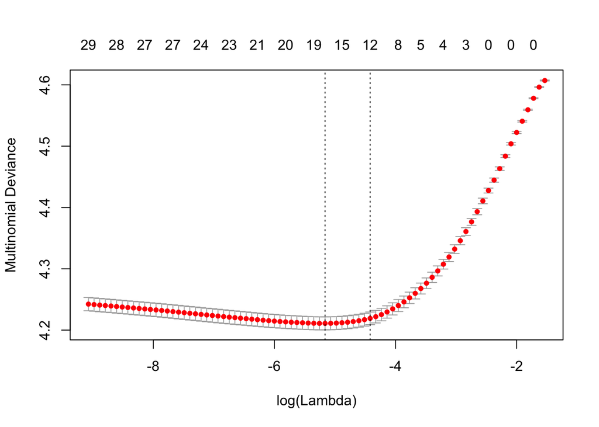

```r
dat_ing$marg <- factor(as.character(dat_ing$marg))
muestra_reng <- sample(1:nrow(dat_ing), 5000)
dat_ing_muestra <- dat_ing[muestra_reng, ]
mat_1 <- model.matrix(~-1+marg+nivelaprob+marg:nivelaprob, data=dat_ing_muestra[,c('marg','nivelaprob')])
mod_decil <- cv.glmnet(y=dat_ing_muestra$decil, x=mat_1 , alpha=0.4, family='multinomial')
plot(mod_decil)
```

Hacemos las predicciones para los datos originales:

```r
mat_2 <- model.matrix(~-1+marg+nivelaprob+marg:nivelaprob, data=dat_ing[,c('marg','nivelaprob')])
mod_decil_pred <- predict(mod_decil, s=exp(-4), type='response', newx=mat_2)[,,1]
head(mod_decil_pred)
```

```
##   [ 0.00, 9.05) [ 9.05, 9.40) [ 9.40, 9.66) [ 9.66, 9.88) [ 9.88,10.08)
## 1    0.04073574    0.05424843    0.09277200    0.09834476    0.11875791
## 2    0.06617930    0.08659228    0.10645957    0.11401747    0.11768832
## 3    0.38894003    0.15846781    0.09356853    0.07293921    0.06723354
## 4    0.01690576    0.02645843    0.03415691    0.04039798    0.04372444
## 5    0.17277241    0.14798149    0.15031355    0.09868615    0.09538580
## 6    0.49699667    0.20692513    0.07116123    0.04309146    0.04165036
##   [10.08,10.28) [10.28,10.51) [10.51,10.76) [10.76,11.14) [11.14,14.35]
## 1    0.15048254    0.12559843    0.12835795    0.11849332    0.07220892
## 2    0.12474380    0.12049852    0.11065690    0.09874146    0.05442238
## 3    0.06066271    0.05679947    0.04341487    0.03418357    0.02379025
## 4    0.04957581    0.04476850    0.04725899    0.07116885    0.62558433
## 5    0.09206181    0.08209613    0.07699826    0.04066827    0.04303614
## 6    0.04019894    0.03518658    0.03091622    0.01508162    0.01879180
```

Y ahora podemos examinar cómo están las predicciones del modelo. Para el decil 10, tenemos las siguientes probabilidades:

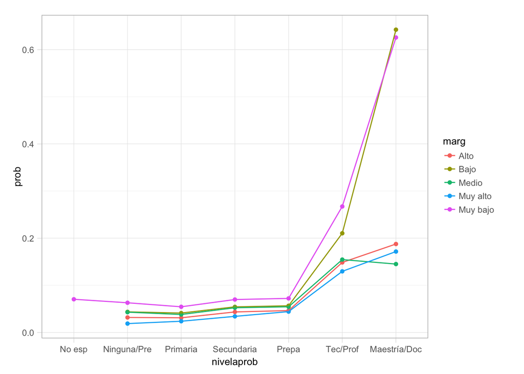

```r
dat_ing$pred.1 <- mod_decil_pred[,10]
dat.res <- ddply(dat_ing, c('marg','nivelaprob'), summarise, prob=mean(pred.1))
ggplot(dat.res, aes(x=nivelaprob, y=prob, colour=marg, group=marg)) + geom_point() +
  geom_line()
```

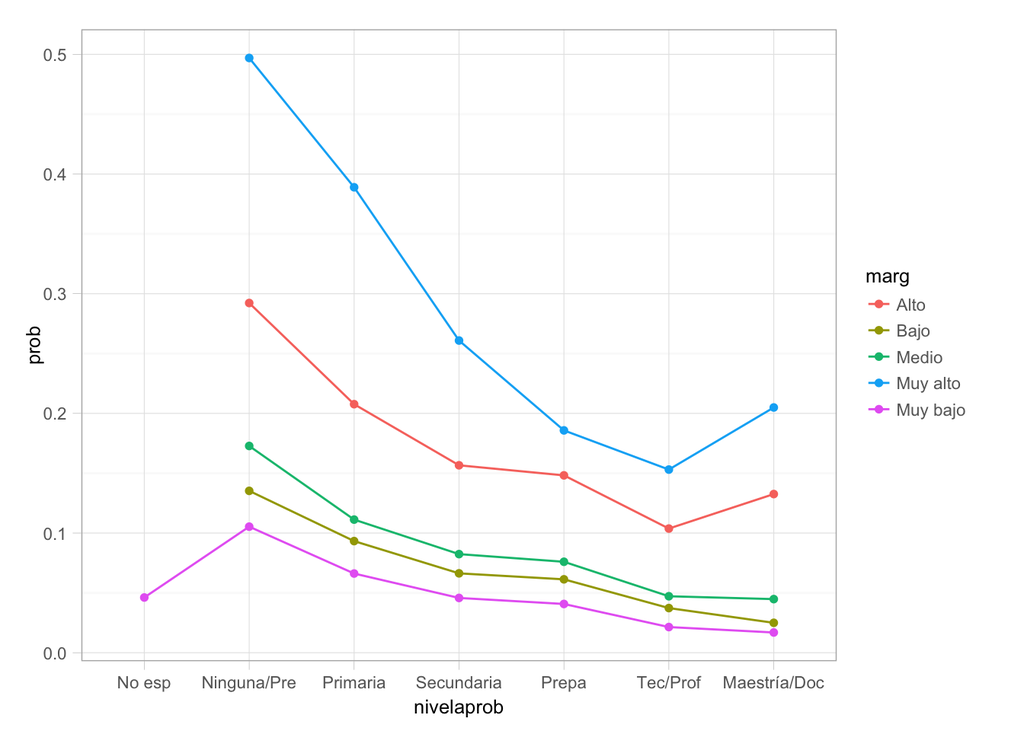

```r
dat_ing$pred_1 <- mod_decil_pred[, 1]
dat_res <- ddply(dat_ing, c('marg','nivelaprob'), summarise, prob=mean(pred_1))
ggplot(dat_res, aes(x=nivelaprob, y=prob, colour=marg, group=marg)) + geom_point() +
  geom_line()
```